# Structure of ant assemblages on street trees in urban Busan, Korea - Park - 2020 - Entomological Research - Wiley Online Library

[Entomological Research](https://onlinelibrary.wiley.com/journal/17485967)

[Volume 50, Issue 3](https://onlinelibrary.wiley.com/toc/17485967/2020/50/3)

[figure not shown]

Research Paper

Full Access

# Structure of ant assemblages on street trees in urban Busan, Korea

[Sang‐Hyun Park](https://onlinelibrary.wiley.com/action/doSearch?ContribAuthorStored=Park%2C+Sang-Hyun)

Correspondence: Sang‐Hyun Park, Department of Biomedical Sciences, Kosin University, Dongsam‐dong, Yeongdo‐gu, Busan, 49104, South Korea. E‐mail:

[Tae‐Young Moon](https://onlinelibrary.wiley.com/action/doSearch?ContribAuthorStored=Moon%2C+Tae-Young)

First published: 20 January 2020

https://doi.org/10.1111/1748-5967.12415

## Abstract

Street trees planted in urban areas are one of the smallest urban green habitats; however, their role as a valuable refuge for local biota is poorly understood. The aim of this study was to investigate urban street trees as habitat for ants. We found ants on 195 (92%) of 211 street trees studied. Seventeen ant species were collected from five tree species. The two most common ant species were *Tetramorium tsushimae* (on 112 trees) and *Lasius japonicus* (on 93 trees). The number of ant species found per tree ranged from 0 to 5, with a mean of 1.55 ± 0.92. The species composition differed significantly among tree species. Nine ant species (*Camponotus vitiosus*, *Lasius alienus*, *L. japonicus*, *Nylanderia flavipes*, *Crematogaster matsumurai*, *Crematogaster vagula*, *Monomorium intrudens*, *T. tsushimae*, and *Brachyponera chinensis*) nested on the trees, mostly in the root zone. Nests were found on 150 trees but were relatively rare on trees with diameter at breast height of less than 40 cm.

## Introduction

Urban areas have been expanding (Botkin & Beveridge 1997; Lumsden & Bennett 2005; Ozanne et al. 2000), which has reduced the amount of vegetation. Remaining vegetation has been fragmented into patches of various sizes and shapes, leaving trees as relatively isolated individuals in the urban matrix (Dickman 1987; Rickman & Connor 2003). Associated with this fragmentation and loss of native vegetation are reductions in the complexity of microclimates and arthropod species richness, as well as a loss of native species and their replacement by exotics (Gibb & Hochuli 2002; McKinney 2006).

Vegetated areas within urban landscapes are increasingly seen as valuable refuges for local biota (Snep et al. 2006; Von Haaren & Reich 2006). Numerous studies have been conducted on arthropod communities in urban forest fragments (Nuckols & Connor 1995; Rickman & Connor 2003; Snep et al. 2006; Yui et al. 2001), residential gardens (Majer & Brown 1986), and clumps of trees in urban parks (McFrederick & LeBuhn 2006; Yamaguchi 2004). It is recognized that planting trees may be the only option to conserve local biota in urban areas, but very few studies have examined arthropod communities on isolated trees planted in urban areas (Bhullar & Majer 2000; Fischer & Lindenmayer 2002; Semlitsch & Bodie 1998).

Ants are found in almost all urban habitats (Klotz et al. 1995; Kondoh & Kitazawa 1984; Na & Lee 2001) and they can exert strong ecological (Folgarait 1998; Sanford et al. 2008) and economical effects (Klotz et al. 2008). In natural habitats, ant species can be predators, prey, detritivores, seed granivores, and herbivores (Alonso 2000; Folgarait 1998). In places where ants are rare, carrion and feces may decompose more slowly and are, therefore, more likely to accumulate than in places where ants are common (Frankie & Ehler 1978). Ants have been successfully used as indicators of ecosystem health under different agricultural practices and of the environmental changes that such practices inadvertently bring (Andersen et al. 2002; Lobry de Bruyn 1999; Peck et al. 1998). Ants can also provide an indication of the richness and types of ecological interactions to which humans in urban areas are exposed. It is important, therefore, to develop our understanding of ants living in urban areas. The aim of this study was to investigate whether street trees act as urban habitats for ants in cities. We sought to understand how the size and species of host trees influence the species richness and composition of ant assemblages. In addition, we evaluated the coexistence of particular sets of ant species on a single tree.

## Materials and methods

The study site was Busan Metropolitan City (35°06′N, 129°06′E), Korea (Fig. 1). The city is located in a warm temperate region with an average annual rainfall of approximately 1519 mm (Korea Meteorological Administration, http://web.kma.go.kr). Seasonality is observed in both temperature and precipitation but winter is not severe, with only light snow and frost. Rainfall is concentrated in the summer (June–September), but there are no extremely dry months in the year.

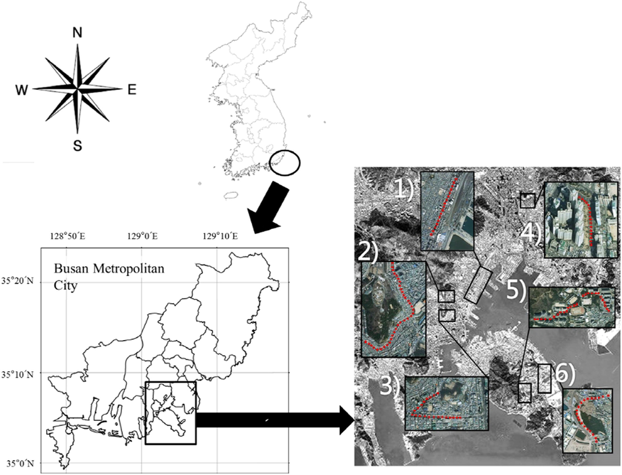

**Figure 1**

Location of the study site and trees within the site: 1) *Ginkgo biloba, Platanus orientalis*; 2) *Prunus × yedoensis*; 3) *Ginkgo biloba*, *Liriodendron tulipifera*, *Machilus thunbergii*; 4) *Ginkgo biloba*, *Machilus thunbergii*; 5) *Prunus × yedoensis*; 6) *Machilus thunbergii*, *Prunus × yedoensis*.

We investigated 211 trees of more than 10 cm in diameter at breast height (DBH) for ant species composition and ant nests. Trees less than 10 cm DBH were not investigated as these would be not suitable for ant nesting (Klimes et al. 2015). Five tree species were investigated: *Prunus* × *yedoensis* (113), *Machilus thunbergii* (38), *Ginkgo biloba* (34), *Liriodendron tulipifera* (15), and *Platanus orientalis* (11) (Table 1).

Table 1. Number, height, and diameter at breast height (DBH) of each street tree species

| Tree species | Number of trees | Number of trees | Height (cm) Mean | Height (cm) Range | DBH (cm) Mean | DBH (cm) Range |
| --- | --- | --- | --- | --- | --- | --- |
| *Prunus* × *yedoensis* | 113 |  | 5.6 | 2–11 | 81.5 | 28–138 |
| *Machilus thunbergii* | 38 |  | 4.8 | 3.5–6 | 54.8 | 39–71 |
| *Ginkgo biloba* | 34 |  | 9.0 | 4.5–12 | 84.5 | 52–124 |
| *Liriodendron tulipifera* | 15 |  | 10.5 | 10–12 | 118.1 | 86–160 |
| *Platanus orientalis* | 11 |  | 10.3 | 10–11 | 94.3 | 67–111 |
| Total | 211 |  | 8.0 |  | 86.6 |  |

Foraging ants were collected from the ground and tree trunks up to 200 cm above the ground, without using bait. No truly nocturnal species occur at the study site, therefore, sampling was conducted during the day, and was assumed to encompass all ant species and their activities. The investigations were carried out between July and October 2015. In all cases, the entrances of nests made in tree trunks and on the ground were visually confirmed.

To compare the species composition among trees, we constructed a similarity matrix using the Bray–Curtis similarity index (Kruskal & Wish 1978) using frequency data for each species. We then used group averaging cluster analysis to display different species assemblages. Significantly different clusters were identified using the similarity profile analysis (SIMPROF) in Primer 6 (Clarke et al. 2008). Additionally, we used Fisher's exact test (McDonald 2009) to test for associations between ant species. Scientific names of ants, and identification and arrangement of ant species, followed the guidelines of the Japanese Ant Database Group (2003).

## Results

### Ant richness, abundance, and species composition

Table 2. Occurrence of ant species and number of nests in street trees (F, foraging; N, nest)

| Ant species | Ant species | Tree species *Prunus × yedoensis* F | Tree species *Prunus × yedoensis* N | Tree species *Machilus thunbergii* F | Tree species *Machilus thunbergii* N | Tree species *Ginkgo biloba* F | Tree species *Ginkgo biloba* N | Tree species *Liriodendron tulipifera* F | Tree species *Liriodendron tulipifera* N | Tree species *Platanus orientalis* F | Tree species *Platanus orientalis* N |
| --- | --- | --- | --- | --- | --- | --- | --- | --- | --- | --- | --- |
| Dolichoderinae | 01 *Ochetellus glaber* | 2 | 0 | 1 | 0 | 0 | 0 | 0 | 0 | 0 | 0 |
| Formicinae | 02 *Camponotus japonicus* | 1 | 0 | 0 | 0 | 0 | 0 | 0 | 0 | 0 | 0 |
|  | 03 *Camponotus vitiosus* | 18 | 0 | 12 | 2 | 0 | 0 | 0 | 0 | 1 | 0 |
|  | 04 *Formica japonica* | 9 | 0 | 4 | 0 | 0 | 0 | 0 | 0 | 0 | 0 |
|  | 05 *Lasius alienus* | 0 | 0 | 3 | 1 | 5 | 0 | 0 | 0 | 1 | 0 |
|  | 06 *Lasius japonicus* | 81 | 46 | 10 | 8 | 0 | 0 | 1 | 0 | 1 | 0 |
|  | 07 *Nylanderia flavipes* | 6 | 3 | 6 | 2 | 0 | 0 | 0 | 0 | 0 | 0 |
| Myrmicinae | 08 *Aphaenogaster famelica* | 3 | 0 | 2 | 0 | 0 | 0 | 0 | 0 | 0 | 0 |
|  | 09 *Crematogaster matsumurai* | 18 | 4 | 7 | 0 | 1 | 0 | 0 | 0 | 0 | 0 |
|  | 10 *Crematogaster vagula* | 7 | 4 | 4 | 1 | 0 | 0 | 0 | 0 | 0 | 0 |
|  | 11 *Monomorium chinense* | 1 | 0 | 0 | 0 | 0 | 0 | 0 | 0 | 0 | 0 |
|  | 12 *Monomorium intrudens* | 0 | 0 | 1 | 1 | 0 | 0 | 0 | 0 | 0 | 0 |
|  | 13 *Pheidole fervida* | 1 | 0 | 0 | 0 | 0 | 0 | 0 | 0 | 0 | 0 |
|  | 14 *Pristomyrmex punctatus* | 4 | 0 | 0 | 0 | 0 | 0 | 0 | 0 | 0 | 0 |
|  | 15 *Tetramorium tsushimae* | 43 | 21 | 23 | 14 | 29 | 20 | 7 | 6 | 10 | 8 |
| Ponerinae | 16 *Brachyponera chinensis* | 2 | 0 | 0 | 0 | 0 | 0 | 0 | 0 | 0 | 0 |
|  | 17 *Hypoponera sauteri* | 6 | 5 | 0 | 0 | 4 | 0 | 0 | 0 | 1 | 0 |
| Number of trees with ants |  | 108/113 |  | 36/38 |  | 33/34 |  | 7/15 |  | 11/11 |  |
| Proportion (%) of trees without ants |  | 4.4 |  | 5.3 |  | 2.9 |  | 53.3 |  | 0 |  |
| Total number of ant species |  | 15 |  | 11 |  | 4 |  | 2 |  | 5 |  |
| Number of species per tree |  | 1.79 ± 0.94 |  | 1.97 ± 0.97 |  | 1.15 ± 0.50 |  | 0.53 ± 0.64 |  | 1.27 ± 0.47 |  |
| Range |  | 0–5 |  | 0–4 |  | 0–3 |  | 0–2 |  | 1–2 |  |
| Total number of trees with ant nests (ground, tree) |  | 63, 24 |  | 28, 1 |  | 20, 0 |  | 6, 0 |  | 8, 0 |  |
| Proportion (%) of trees with nests |  | 55.8, 21.2 |  | 73.7. 2.6 |  | 58.8, 0.0 |  | 40.0, 0.0 |  | 72.7, 0.0 |  |

- F, foraging; N, nest

The number of ant species found per tree ranged from 0 to 5, with a mean of 1.55 ± 0.92. The average species richness of each tree species ranged from 0.53 ± 0.64 for *L. tulipifera* to 1.97 ± 0.97 for *M. thunbergii*. At least one ant species was observed on most trees: *P. orientalis* (100%)*, G. biloba* (97.1%)*, P*. × *yedoensis* (95.6%), and *M*. *thunbergii* (94.7%). In contrast, ants were found on fewer than half of *L. tulipifera* trees.

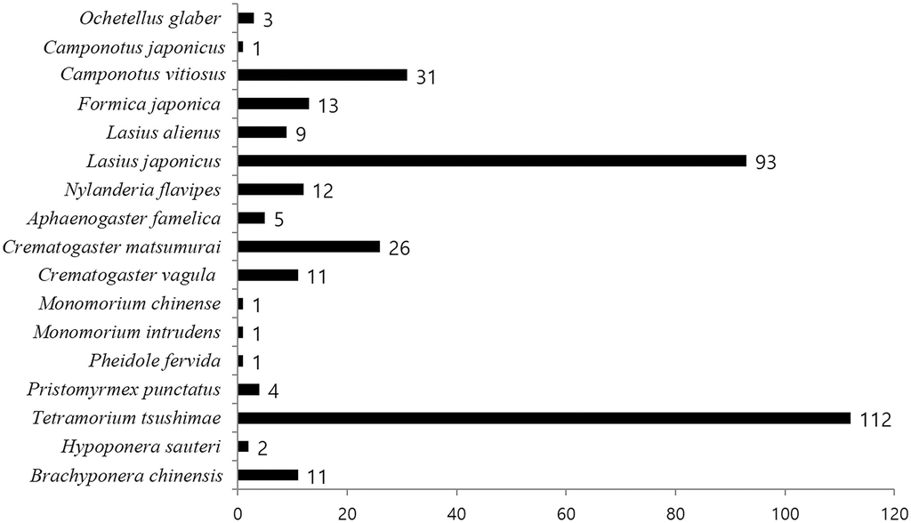

**Figure 2**

Ant species foraging on street trees planted in urban Busan, Korea.

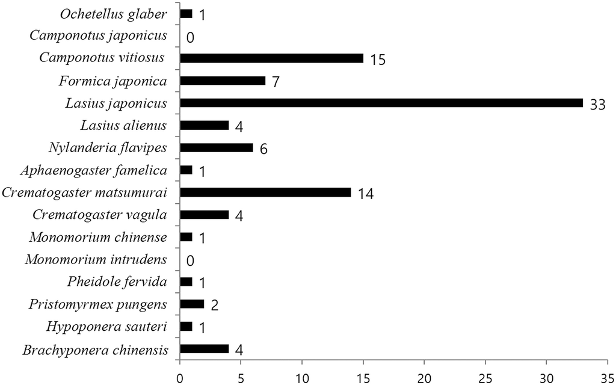

**Figure 3**

Ant species found with *Tetramorium tsushimae* on 112 street trees.

The cluster analysis separated ant assemblages into two groups: *P*. × *yedoensis*, *M*. *thunbergii*, and *G. biloba*, and *L. tulipifera* and *P. orientalis* (Fig. 4). The SIMPROF test showed that the ant species composition differed significantly among the tree species (*P* < 0.05).

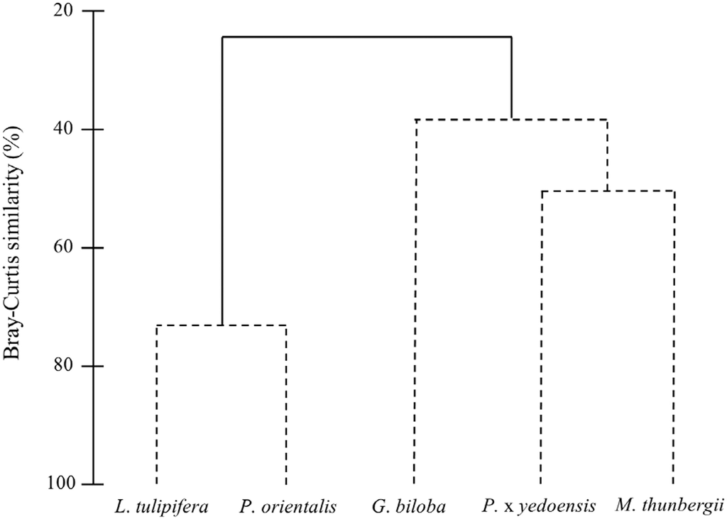

**Figure 4**

Cluster analysis based on Bray–Curtis similarity in ant species composition among trees. The dotted lines indicate no significant difference among the trees (SIMPROF test). Species included are *Liriodendron tulipifera*, *Platanus orientalis, Ginkgo biloba, Prunus × yedoensis* and *Machilus thunbergii*

### Nests

Table 3. Number of ant nests on 211 street trees by size class (DBH)

| Ant species | DBH (cm) 20–40 | DBH (cm) 40–60 | DBH (cm) 60–80 | DBH (cm) 80–100 | DBH (cm) over 100 |
| --- | --- | --- | --- | --- | --- |
| *Camponotus vitiosus* | 0 | 0 | 2 | 0 | 0 |
| *Lasius japonicus* | 0 | 18 | 10 | 17 | 13 |
| *Lasius alienus* | 0 | 0 | 1 | 0 | 0 |
| *Nylanderia flavipes* | 2 | 2 | 0 | 1 | 0 |
| *Crematogaster matsumurai* | 0 | 0 | 2 | 1 | 2 |
| *Crematogaster vagula* | 0 | 0 | 3 | 1 | 0 |
| *Monomorium intrudens* | 0 | 1 | 0 | 0 | 0 |
| *Tetramorium tsushimae* | 0 | 17 | 16 | 18 | 18 |
| *Brachyponera chinensis* | 0 | 1 | 0 | 3 | 1 |
| Total number of ant nests | 2 | 39 | 34 | 41 | 34 |
| Number of trees | 5 | 47 | 53 | 52 | 54 |
| Proportion (%) of trees with nests | 40.0 | 83.0 | 64.2 | 78.8 | 63.0 |

## Discussion

In the present study, 17 ant species belonging to 13 genera were observed on urban street trees in Busan. Harada (2011) and Iwata et al. (2005) reported 15 species from trees at Joyama Park and 18 species from trees at Nanatsujima Park, Kagoshima City, Japan, where climate conditions are similar to those of our study site. The mean number of ant species per tree was also not distinctly different between these studies (Joyama Park, 1.83 with a range from 0 to 6; Nanatsujima Park, 2.07 with a range from 1 to 7). These figures thus represent a typical number of ant species found on street trees in urbanized areas in Korea and Japan. However, the ant richness and composition were influenced by tree species and size.

In conclusion, the structure of ant assemblages on street trees planted in urban areas is influenced by the species of tree. In addition, the ant species that coexist on a single tree vary. The potential value of street trees for urban biodiversity must be recognized.

## References

[figure not shown]

March 2020

Pages 131-137